# 1 数据获取

### 1.1 数据集简介

数据集来自UCI加州大学欧文分校机器学习库，该数据集为英国在线零售商在2010年12月1日至2011年12月9日间发生的所有网络交易订单信息，包括客户编号、订单编号、商品代码及数量、单价等字段。该公司主要销售礼品，拥有许多批发商客户。

### 1.2 数据集内容

- InvoiceNo：发票编号。为每笔订单唯一分配的6位整数。若以字母'C'开头，则表示该订单被取消。
- StockCode：产品代码。为每个产品唯一分配的编码。
- Description：产品描述。
- Quantity：数量。每笔订单中各产品分别的数量。
- InvoiceDate：发票日期和时间。每笔订单发生的日期和时间。
- UnitPrice：单价。单位产品价格，单位为英镑。
- CustomerID：客户编号。为每个客户唯一分配的5位整数。
- Country：国家。客户所在国家/地区的名称。

# 2. 提出问题

根据数据集提出问题如下：

1.订单维度：笔单价和连带率是多少？订单金额与订单内商品件数的关系如何？

2.客户维度：客单价是多少？客户消费金额与消费件数的关系如何？

3.商品维度：商品的价格定位是高是低？哪种价位的商品卖得好？哪种价位的商品带来了实际上最多的销售额？

4.时间维度：各月/各日的销售情况是什么走势？可能受到了什么影响？

5.区位维度：客户主要来自哪几个国家？哪个国家是境外主要市场？哪个国家的客户平均消费能力最强？

6.客户行为：客户的生命周期、留存情况、购买周期如何？

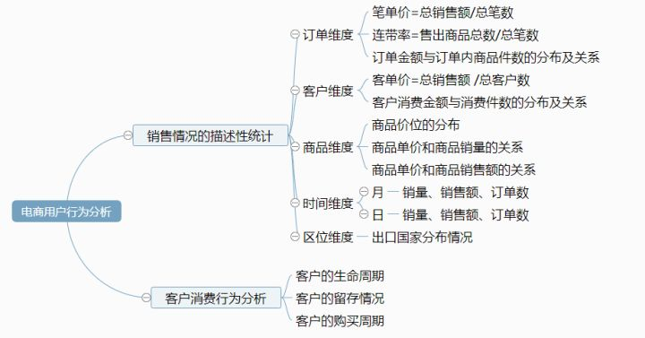

# 3 清洗数据

数据清洗部分思路如下：

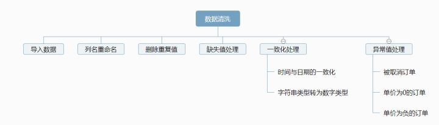

### 3.1 导入数据

```python
import pandas as pd
import numpy as np
```

```python
sales_df = pd.read_excel('./Online Retail.xlsx', sheet_name='Online Retail', dtype=str)
```

```python
sales_df.head()
```

|  | InvoiceNo | StockCode | Description | Quantity | InvoiceDate | UnitPrice | CustomerID | Country |
| --- | --- | --- | --- | --- | --- | --- | --- | --- |
| 0 | 536365 | 85123A | WHITE HANGING HEART T-LIGHT HOLDER | 6 | 2010-12-01 08:26:00 | 2.55 | 17850 | United Kingdom |
| 1 | 536365 | 71053 | WHITE METAL LANTERN | 6 | 2010-12-01 08:26:00 | 3.39 | 17850 | United Kingdom |
| 2 | 536365 | 84406B | CREAM CUPID HEARTS COAT HANGER | 8 | 2010-12-01 08:26:00 | 2.75 | 17850 | United Kingdom |
| 3 | 536365 | 84029G | KNITTED UNION FLAG HOT WATER BOTTLE | 6 | 2010-12-01 08:26:00 | 3.39 | 17850 | United Kingdom |
| 4 | 536365 | 84029E | RED WOOLLY HOTTIE WHITE HEART. | 6 | 2010-12-01 08:26:00 | 3.39 | 17850 | United Kingdom |

再查看一下各列的数据类型，由于前面导入文件时指定了数据类型dtype=str，这里dataframe中各列的数据类型应该都为object：

```python
sales_df.dtypes
```

```
InvoiceNo      object
StockCode      object
Description    object
Quantity       object
InvoiceDate    object
UnitPrice      object
CustomerID     object
Country        object
dtype: object
```

### 3.2 列名重命名

观察到字段InvoiceDate并非只包含了日期信息，同时也涵盖了具体的时分秒维度，故将其重命名为InvoiceTime：

```python
sales_df.rename(columns={'InvoiceDate':'InvoiceTime'},inplace=True)
```

### 3.3 删除重复值

我们规定，若所有字段的值都完全相同，则视为重复数据，仅保留一条。

删除重复值，并根据去重前后的行数变化计算重复值数量：

```python
rows_before = sales_df.shape[0]
sales_df.drop_duplicates(inplace=True)
rows_after = sales_df.shape[0]
print('原行数：', rows_before, '现行数：', rows_after, '删除行数:', rows_before - rows_after)
```

```
原行数： 541909 现行数： 536641 删除行数: 5268
```

共删去重复值5268条。

由于重复数据的删除，此时索引值和行数已不相符，进行索引的重设，并删除原索引：

```python
sales_df.reset_index(drop=True,inplace=True)
```

### 3.4 缺失值处理

查看是否存在缺失值：

```python
sales_df.isnull().sum()
```

```
InvoiceNo      0
StockCode      0
Description    0
Quantity       0
InvoiceTime    0
UnitPrice      0
CustomerID     0
Country        0
dtype: int64
```

不存在缺失值，故不需要特殊处理

### 3.5 一致化处理

##### 3.5.1 时间相关信息的一致化

首先将InvoiceTime转为pandas能处理的时间格式datetime：

```python
sales_df['InvoiceTime'] = pd.to_datetime(sales_df['InvoiceTime'],errors='coerce')
```

再新增字段Date存放InvoiceTime中的日期部分：

```python
sales_df['Date'] = pd.to_datetime(sales_df['InvoiceTime'].dt.date,errors='coerce')
```

新增Month存放月份信息：

```python
sales_df['Month'] = sales_df['InvoiceTime'].dt.month
```

由于我们对时间相关字段的操作有可能产生缺失值，再次查看缺失值情况sales_df.head()

```python
sales_df.isnull().sum()
```

```
InvoiceNo      0
StockCode      0
Description    0
Quantity       0
InvoiceTime    0
UnitPrice      0
CustomerID     0
Country        0
Date           0
Month          0
dtype: int64
```

##### 3.5.2 字符串类型转为数字类型

首先查看当前各字段的数据类型：

```python
sales_df.dtypes
```

```
InvoiceNo              object
StockCode              object
Description            object
Quantity               object
InvoiceTime    datetime64[ns]
UnitPrice              object
CustomerID             object
Country                object
Date           datetime64[ns]
Month                   int64
dtype: object
```

看到Quantity数量、UnitPrice单价、CustomerID客户编号是object格式，将UnitPrice转为浮点型，Quantity和CustomerID转为整型：

```python
sales_df['Quantity'] = sales_df['Quantity'].astype('int32')
sales_df['UnitPrice'] = sales_df['UnitPrice'].astype('float')
```

CustomerID无法转换，经检查发现，CustomerID有nan值，需对其进行转化

```python
sales_df['CustomerID'].value_counts()
```

```
nan      135037
17841      7812
14911      5898
14096      5128
12748      4459
14606      2759
15311      2478
14646      2085
13089      1853
13263      1667
14298      1640
15039      1483
14156      1415
18118      1268
14159      1183
```

[output cut: 47 more lines]

```python
sales_df[sales_df['CustomerID'] == '0']
```

|  | InvoiceNo | StockCode | Description | Quantity | InvoiceTime | UnitPrice | CustomerID | Country | Date | Month |
| --- | --- | --- | --- | --- | --- | --- | --- | --- | --- | --- |

得到了一个空的表头，说明不存在ID为‘0’的客户。

```python
sales_df['CustomerID'].replace('nan','0',inplace=True)
```

接下来转换为int

```python
sales_df['CustomerID'] = sales_df['CustomerID'].astype('int32')
```

增加字段SumPrice用于存放该行数据的总价：

```python
sales_df['SumPrice'] = sales_df['Quantity'] * sales_df['UnitPrice']
```

### 3.6 异常值处理

为了探究是否存在异常值，我们查看总体的描述性统计情况：

```python
sales_df.describe()
```

|  | Quantity | UnitPrice | CustomerID | Month | SumPrice |
| --- | --- | --- | --- | --- | --- |
| count | 536641.000000 | 536641.000000 | 536641.000000 | 536641.000000 | 536641.000000 |
| mean | 9.620029 | 4.632656 | 11435.904653 | 7.544820 | 18.123861 |
| std | 219.130156 | 97.233118 | 6795.044250 | 3.508696 | 380.656263 |
| min | -80995.000000 | -11062.060000 | 0.000000 | 1.000000 | -168469.600000 |
| 25% | 1.000000 | 1.250000 | 0.000000 | 5.000000 | 3.750000 |
| 50% | 3.000000 | 2.080000 | 14336.000000 | 8.000000 | 9.870000 |
| 75% | 10.000000 | 4.130000 | 16241.000000 | 11.000000 | 17.400000 |
| max | 80995.000000 | 38970.000000 | 18287.000000 | 12.000000 | 168469.600000 |

发现Quantity数量、UnitPrice单价、SumPrice总价都存在负值的情况，且绝对值较大。而总价是由数量和单价相乘得到，总价为负实际上也是数量和单价二者之一为负值导致的。

故查看数量或单价非正值的数据：

```python
sales_df[sales_df['Quantity']<=0 | (sales_df['UnitPrice'] <= 0)]
```

|  | InvoiceNo | StockCode | Description | Quantity | InvoiceTime | UnitPrice | CustomerID | Country | Date | Month | SumPrice |
| --- | --- | --- | --- | --- | --- | --- | --- | --- | --- | --- | --- |
| 141 | C536379 | D | Discount | -1 | 2010-12-01 09:41:00 | 27.50 | 14527 | United Kingdom | 2010-12-01 | 12 | -27.50 |
| 154 | C536383 | 35004C | SET OF 3 COLOURED FLYING DUCKS | -1 | 2010-12-01 09:49:00 | 4.65 | 15311 | United Kingdom | 2010-12-01 | 12 | -4.65 |
| 235 | C536391 | 22556 | PLASTERS IN TIN CIRCUS PARADE | -12 | 2010-12-01 10:24:00 | 1.65 | 17548 | United Kingdom | 2010-12-01 | 12 | -19.80 |
| 236 | C536391 | 21984 | PACK OF 12 PINK PAISLEY TISSUES | -24 | 2010-12-01 10:24:00 | 0.29 | 17548 | United Kingdom | 2010-12-01 | 12 | -6.96 |
| 237 | C536391 | 21983 | PACK OF 12 BLUE PAISLEY TISSUES | -24 | 2010-12-01 10:24:00 | 0.29 | 17548 | United Kingdom | 2010-12-01 | 12 | -6.96 |
| 238 | C536391 | 21980 | PACK OF 12 RED RETROSPOT TISSUES | -24 | 2010-12-01 10:24:00 | 0.29 | 17548 | United Kingdom | 2010-12-01 | 12 | -6.96 |
| 239 | C536391 | 21484 | CHICK GREY HOT WATER BOTTLE | -12 | 2010-12-01 10:24:00 | 3.45 | 17548 | United Kingdom | 2010-12-01 | 12 | -41.40 |
| 240 | C536391 | 22557 | PLASTERS IN TIN VINTAGE PAISLEY | -12 | 2010-12-01 10:24:00 | 1.65 | 17548 | United Kingdom | 2010-12-01 | 12 | -19.80 |
| 241 | C536391 | 22553 | PLASTERS IN TIN SKULLS | -24 | 2010-12-01 10:24:00 | 1.65 | 17548 | United Kingdom | 2010-12-01 | 12 | -39.60 |
| 916 | C536506 | 22960 | JAM MAKING SET WITH JARS | -6 | 2010-12-01 12:38:00 | 4.25 | 17897 | United Kingdom | 2010-12-01 | 12 | -25.50 |
| 1405 | C536543 | 22632 | HAND WARMER RED RETROSPOT | -1 | 2010-12-01 14:30:00 | 2.10 | 17841 | United Kingdom | 2010-12-01 | 12 | -2.10 |
| 1406 | C536543 | 22355 | CHARLOTTE BAG SUKI DESIGN | -2 | 2010-12-01 14:30:00 | 0.85 | 17841 | United Kingdom | 2010-12-01 | 12 | -1.70 |
| 1934 | 536545 | 21134 | nan | 1 | 2010-12-01 14:32:00 | 0.00 | 0 | United Kingdom | 2010-12-01 | 12 | 0.00 |
| 1935 | 536546 | 22145 | nan | 1 | 2010-12-01 14:33:00 | 0.00 | 0 | United Kingdom | 2010-12-01 | 12 | 0.00 |
| 1936 | 536547 | 37509 | nan | 1 | 2010-12-01 14:33:00 | 0.00 | 0 | United Kingdom | 2010-12-01 | 12 | 0.00 |
| 1937 | C536548 | 22244 | 3 HOOK HANGER MAGIC GARDEN | -4 | 2010-12-01 14:33:00 | 1.95 | 12472 | Germany | 2010-12-01 | 12 | -7.80 |
| 1938 | C536548 | 22242 | 5 HOOK HANGER MAGIC TOADSTOOL | -5 | 2010-12-01 14:33:00 | 1.65 | 12472 | Germany | 2010-12-01 | 12 | -8.25 |
| 1939 | C536548 | 20914 | SET/5 RED RETROSPOT LID GLASS BOWLS | -1 | 2010-12-01 14:33:00 | 2.95 | 12472 | Germany | 2010-12-01 | 12 | -2.95 |
| 1940 | C536548 | 22892 | SET OF SALT AND PEPPER TOADSTOOLS | -7 | 2010-12-01 14:33:00 | 1.25 | 12472 | Germany | 2010-12-01 | 12 | -8.75 |
| 1941 | C536548 | 22654 | DELUXE SEWING KIT | -1 | 2010-12-01 14:33:00 | 5.95 | 12472 | Germany | 2010-12-01 | 12 | -5.95 |
| 1942 | C536548 | 22767 | TRIPLE PHOTO FRAME CORNICE | -2 | 2010-12-01 14:33:00 | 9.95 | 12472 | Germany | 2010-12-01 | 12 | -19.90 |
| 1943 | C536548 | 22333 | RETROSPOT PARTY BAG + STICKER SET | -1 | 2010-12-01 14:33:00 | 1.65 | 12472 | Germany | 2010-12-01 | 12 | -1.65 |
| 1944 | C536548 | 22245 | HOOK, 1 HANGER ,MAGIC GARDEN | -2 | 2010-12-01 14:33:00 | 0.85 | 12472 | Germany | 2010-12-01 | 12 | -1.70 |
| 1945 | C536548 | 22077 | 6 RIBBONS RUSTIC CHARM | -6 | 2010-12-01 14:33:00 | 1.65 | 12472 | Germany | 2010-12-01 | 12 | -9.90 |
| 1946 | C536548 | 22631 | CIRCUS PARADE LUNCH BOX | -1 | 2010-12-01 14:33:00 | 1.95 | 12472 | Germany | 2010-12-01 | 12 | -1.95 |
| 1947 | C536548 | 22168 | ORGANISER WOOD ANTIQUE WHITE | -2 | 2010-12-01 14:33:00 | 8.50 | 12472 | Germany | 2010-12-01 | 12 | -17.00 |
| 1948 | C536548 | 21218 | RED SPOTTY BISCUIT TIN | -3 | 2010-12-01 14:33:00 | 3.75 | 12472 | Germany | 2010-12-01 | 12 | -11.25 |
| 1949 | C536548 | 20957 | PORCELAIN HANGING BELL SMALL | -1 | 2010-12-01 14:33:00 | 1.45 | 12472 | Germany | 2010-12-01 | 12 | -1.45 |
| 1950 | C536548 | 22580 | ADVENT CALENDAR GINGHAM SACK | -4 | 2010-12-01 14:33:00 | 5.95 | 12472 | Germany | 2010-12-01 | 12 | -23.80 |
| 1951 | 536549 | 85226A | nan | 1 | 2010-12-01 14:34:00 | 0.00 | 0 | United Kingdom | 2010-12-01 | 12 | 0.00 |
| ... | ... | ... | ... | ... | ... | ... | ... | ... | ... | ... | ... |
| 533320 | C581409 | 22173 | METAL 4 HOOK HANGER FRENCH CHATEAU | -2 | 2011-12-08 14:08:00 | 3.29 | 12476 | Germany | 2011-12-08 | 12 | -6.58 |
| 533321 | C581409 | 85199L | LARGE HANGING IVORY & RED WOOD BIRD | -1 | 2011-12-08 14:08:00 | 0.65 | 12476 | Germany | 2011-12-08 | 12 | -0.65 |
| 533322 | C581409 | 85127 | SMALL SQUARE CUT GLASS CANDLESTICK | -5 | 2011-12-08 14:08:00 | 4.95 | 12476 | Germany | 2011-12-08 | 12 | -24.75 |
| 533665 | 581422 | 23169 | smashed | -235 | 2011-12-08 15:24:00 | 0.00 | 0 | United Kingdom | 2011-12-08 | 12 | -0.00 |
| 534812 | C581460 | 22197 | POPCORN HOLDER | -5 | 2011-12-08 18:48:00 | 0.72 | 13078 | United Kingdom | 2011-12-08 | 12 | -3.60 |
| 534813 | C581460 | 22107 | PIZZA PLATE IN BOX | -1 | 2011-12-08 18:48:00 | 1.25 | 13078 | United Kingdom | 2011-12-08 | 12 | -1.25 |
| 534818 | C581462 | 16219 | HOUSE SHAPE PENCIL SHARPENER | -48 | 2011-12-08 18:51:00 | 0.06 | 12985 | United Kingdom | 2011-12-08 | 12 | -2.88 |
| 534819 | C581462 | 21642 | ASSORTED TUTTI FRUTTI PEN | -72 | 2011-12-08 18:51:00 | 0.29 | 12985 | United Kingdom | 2011-12-08 | 12 | -20.88 |
| 534820 | C581463 | 85048 | 15CM CHRISTMAS GLASS BALL 20 LIGHTS | -2 | 2011-12-08 18:56:00 | 7.95 | 17526 | United Kingdom | 2011-12-08 | 12 | -15.90 |
| 534821 | C581464 | 23458 | DOLLY CABINET 3 DRAWERS | -1 | 2011-12-08 18:57:00 | 14.95 | 15951 | United Kingdom | 2011-12-08 | 12 | -14.95 |
| 534822 | C581464 | 71477 | COLOURED GLASS STAR T-LIGHT HOLDER | -6 | 2011-12-08 18:57:00 | 3.95 | 15951 | United Kingdom | 2011-12-08 | 12 | -23.70 |
| 534823 | C581465 | 23660 | HENRIETTA HEN MUG | -2 | 2011-12-08 18:59:00 | 1.65 | 15755 | United Kingdom | 2011-12-08 | 12 | -3.30 |
| 534824 | C581465 | 22171 | 3 HOOK PHOTO SHELF ANTIQUE WHITE | -1 | 2011-12-08 18:59:00 | 8.50 | 15755 | United Kingdom | 2011-12-08 | 12 | -8.50 |
| 534825 | C581465 | 21876 | POTTERING MUG | -4 | 2011-12-08 18:59:00 | 1.65 | 15755 | United Kingdom | 2011-12-08 | 12 | -6.60 |
| 534826 | C581465 | 20914 | SET/5 RED RETROSPOT LID GLASS BOWLS | -3 | 2011-12-08 18:59:00 | 2.95 | 15755 | United Kingdom | 2011-12-08 | 12 | -8.85 |
| 534827 | C581466 | 22838 | 3 TIER CAKE TIN RED AND CREAM | -1 | 2011-12-08 19:20:00 | 14.95 | 13883 | United Kingdom | 2011-12-08 | 12 | -14.95 |
| 534828 | C581466 | 22720 | SET OF 3 CAKE TINS PANTRY DESIGN | -2 | 2011-12-08 19:20:00 | 4.95 | 13883 | United Kingdom | 2011-12-08 | 12 | -9.90 |
| 534829 | C581466 | 21216 | SET 3 RETROSPOT TEA,COFFEE,SUGAR | -1 | 2011-12-08 19:20:00 | 4.95 | 13883 | United Kingdom | 2011-12-08 | 12 | -4.95 |
| 534830 | C581466 | 21535 | RED RETROSPOT SMALL MILK JUG | -2 | 2011-12-08 19:20:00 | 2.55 | 13883 | United Kingdom | 2011-12-08 | 12 | -5.10 |
| 534831 | C581466 | 21232 | STRAWBERRY CERAMIC TRINKET POT | -1 | 2011-12-08 19:20:00 | 1.25 | 13883 | United Kingdom | 2011-12-08 | 12 | -1.25 |
| 534881 | C581468 | 21314 | SMALL GLASS HEART TRINKET POT | -10 | 2011-12-08 19:26:00 | 2.10 | 13599 | United Kingdom | 2011-12-08 | 12 | -21.00 |
| 534882 | C581468 | 22098 | BOUDOIR SQUARE TISSUE BOX | -12 | 2011-12-08 19:26:00 | 0.39 | 13599 | United Kingdom | 2011-12-08 | 12 | -4.68 |
| 534916 | C581470 | 23084 | RABBIT NIGHT LIGHT | -4 | 2011-12-08 19:28:00 | 2.08 | 17924 | United Kingdom | 2011-12-08 | 12 | -8.32 |
| 535161 | C581484 | 23843 | PAPER CRAFT , LITTLE BIRDIE | -80995 | 2011-12-09 09:27:00 | 2.08 | 16446 | United Kingdom | 2011-12-09 | 12 | -168469.60 |
| 535187 | C581490 | 22178 | VICTORIAN GLASS HANGING T-LIGHT | -12 | 2011-12-09 09:57:00 | 1.95 | 14397 | United Kingdom | 2011-12-09 | 12 | -23.40 |
| 535188 | C581490 | 23144 | ZINC T-LIGHT HOLDER STARS SMALL | -11 | 2011-12-09 09:57:00 | 0.83 | 14397 | United Kingdom | 2011-12-09 | 12 | -9.13 |
| 536280 | C581499 | M | Manual | -1 | 2011-12-09 10:28:00 | 224.69 | 15498 | United Kingdom | 2011-12-09 | 12 | -224.69 |
| 536447 | C581568 | 21258 | VICTORIAN SEWING BOX LARGE | -5 | 2011-12-09 11:57:00 | 10.95 | 15311 | United Kingdom | 2011-12-09 | 12 | -54.75 |
| 536448 | C581569 | 84978 | HANGING HEART JAR T-LIGHT HOLDER | -1 | 2011-12-09 11:58:00 | 1.25 | 17315 | United Kingdom | 2011-12-09 | 12 | -1.25 |
| 536449 | C581569 | 20979 | 36 PENCILS TUBE RED RETROSPOT | -5 | 2011-12-09 11:58:00 | 1.25 | 17315 | United Kingdom | 2011-12-09 | 12 | -6.25 |

10987 rows × 11 columns

初步浏览，注意到主要是 ①C字头的被取消订单 和 ②单价为0的免费订单 导致的异常

##### 3.6.1 C字头的取消订单

取消订单产生的负值在之后销售情况的分析中会产生干扰，考虑将sales_df分为只含成功订单和只含取消订单两部分。我们需要探究取消订单是直接在原订单上进行的修改，还是用来抵消原订单的新增数据。以上图第一行为例来说，即是否存在536379订单，与C536379订单对应。

将sales_df分为成功订单和取消订单两部分，划分依据是发票编号InvoiceNo是否含有“C”:

```python
query_c = sales_df['InvoiceNo'].str.contains('C')
# 只含取消订单
sales_cancel = sales_df.loc[query_c,:].copy()
# 只含成功订单
sales_success = sales_df.loc[-query_c,:].copy()
```

为sales_cancel增加字段SrcInvoiceNo，用于存放去掉“C”的发票编号：

```python
sales_cancel['SrcInvoiceNo'] = sales_cancel['InvoiceNo'].str.split('C',expand=True)[1]
```

将sales_cancel和sales_success进行合并：

```python
pd.merge(sales_cancel, sales_success, left_on='SrcInvoiceNo',right_on='InvoiceNo')
```

|  | InvoiceNo_x | StockCode_x | Description_x | Quantity_x | InvoiceTime_x | UnitPrice_x | CustomerID_x | Country_x | Date_x | Month_x | ... | StockCode_y | Description_y | Quantity_y | InvoiceTime_y | UnitPrice_y | CustomerID_y | Country_y | Date_y | Month_y | SumPrice_y |
| --- | --- | --- | --- | --- | --- | --- | --- | --- | --- | --- | --- | --- | --- | --- | --- | --- | --- | --- | --- | --- | --- |

0 rows × 23 columns

可以确认发现取消订单和成功订单并无对应关系。

```python
print('取消订单数:',sales_cancel.shape[0],';成功订单数：',sales_success.shape[0])
```

```
取消订单数: 9251 ;成功订单数： 527390
```

##### 3.6.2 单价为0的免费订单

推测单价为0的订单是促销活动的赠品，对于订单量、件单价、连带率等指标的计算造成干扰，故也单独分出一张表存放，之后再对免费订单进行分析：

```python
query_free = sales_success['UnitPrice'] == 0
# 只含免费订单
sales_cancel = sales_success.loc[query_free,:].copy()
# 只含普通订单
sales_success = sales_success.loc[-query_free,:]
```

```python
sales_success.describe()
```

|  | Quantity | UnitPrice | CustomerID | Month | SumPrice |
| --- | --- | --- | --- | --- | --- |
| count | 524880.000000 | 524880.000000 | 524880.000000 | 524880.000000 | 524880.000000 |
| mean | 10.616564 | 3.880407 | 11437.688582 | 7.552239 | 20.233171 |
| std | 156.279734 | 42.063124 | 6799.537329 | 3.508158 | 272.552926 |
| min | 1.000000 | -11062.060000 | 0.000000 | 1.000000 | -11062.060000 |
| 25% | 1.000000 | 1.250000 | 0.000000 | 5.000000 | 3.900000 |
| 50% | 4.000000 | 2.080000 | 14350.000000 | 8.000000 | 9.920000 |
| 75% | 11.000000 | 4.130000 | 16245.000000 | 11.000000 | 17.700000 |
| max | 80995.000000 | 13541.330000 | 18287.000000 | 12.000000 | 168469.600000 |

注意到还有一类异常订单，单价为负值。

###### 3.6.3 单价为负的订单

查询出此类订单：

```python
query_minus = sales_success['UnitPrice'] < 0
sales_success.loc[query_minus,:]
```

|  | InvoiceNo | StockCode | Description | Quantity | InvoiceTime | UnitPrice | CustomerID | Country | Date | Month | SumPrice |
| --- | --- | --- | --- | --- | --- | --- | --- | --- | --- | --- | --- |
| 297646 | A563186 | B | Adjust bad debt | 1 | 2011-08-12 14:51:00 | -11062.06 | 0 | United Kingdom | 2011-08-12 | 8 | -11062.06 |
| 297647 | A563187 | B | Adjust bad debt | 1 | 2011-08-12 14:52:00 | -11062.06 | 0 | United Kingdom | 2011-08-12 | 8 | -11062.06 |

发现是两笔相邻且金额相同的A字头订单。数据集的说明文字中并未提及过A字头订单的存在，从Description描述中得知是用来调整坏账的，故直接将其筛去：

```python
sales_success = sales_success.loc[-query_minus,:]
```

至此数据清洗告一段落

```python
sales_success.shape
```

```
(524878, 11)
```

sales_success还余524878行数据：

# 4. 分析与可视化

## 4.1 销售情况的描述性统计

### 4.1.1 订单维度

首先将sales_success按订单号分组，对Quantity商品数量和SumPrice总价分组求和：

```python
invoice_grouped = sales_success.groupby('InvoiceNo')[['Quantity', 'SumPrice']].sum()
```

通过describe获得笔单价（每笔订单的平均交易金额）和连带率（每笔订单平均购买的产品件数）：

```python
# 笔单价 与 连带率
# 笔单价 = 总销售额 / 总笔数
# 连带率 = 售出商品总数 / 总笔数
invoice_grouped.describe()
```

|  | Quantity | SumPrice |
| --- | --- | --- |
| count | 19960.000000 | 19960.000000 |
| mean | 279.179359 | 533.171884 |
| std | 955.011810 | 1780.412288 |
| min | 1.000000 | 0.380000 |
| 25% | 69.000000 | 151.695000 |
| 50% | 150.000000 | 303.300000 |
| 75% | 296.000000 | 493.462500 |
| max | 80995.000000 | 168469.600000 |

统计区间（2010年12月1日-2011年12月9日）内共产生有效订单19960笔，笔单价为533.17英镑，连带率约为279件，说明以批发性质的订单为主。订单交易金额和订单内商品件数，其均值都高于中位数；订单交易金额的均值甚至高于Q3分位数。说明订单总体差异大，存在部分购买力极强的客户。

接下来绘制订单交易金额的分布图：

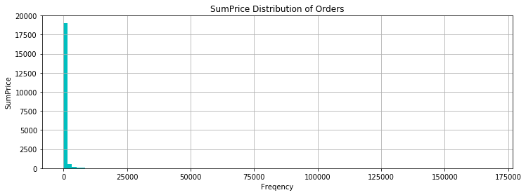

```python
import matplotlib.pyplot as plt
invoice_grouped['SumPrice'].hist(bins=100,figsize=(12,4),color='c')
plt.title('SumPrice Distribution of Orders')
plt.xlabel('Freqency')
plt.ylabel('SumPrice')
```

部分订单交易金额过大，影响图表的可读性，筛去1000英镑及以上的订单：

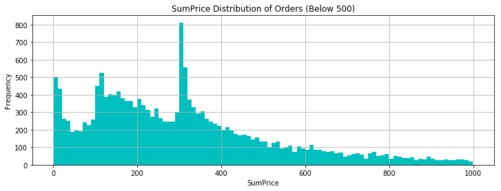

```python
invoice_grouped[invoice_grouped.SumPrice < 1000]['SumPrice'].hist(bins = 100, figsize = (12, 4), color = 'c')
plt.title('SumPrice Distribution of Orders (Below 500)')
plt.ylabel('Frequency')
plt.xlabel('SumPrice')
```

订单金额集中在400英镑内，三个峰值分别为20英镑内、100-230英镑、300-320英镑。其中300-320英镑的订单数量特别多，不知道是否存在某种共性，之后可以进行进一步探究。

对订单内商品数量的分布同样绘制柱形图：

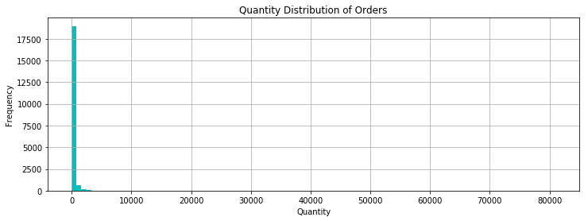

```python
invoice_grouped['Quantity'].hist(bins = 100, figsize = (12, 4), color = 'c')
plt.title('Quantity Distribution of Orders')
plt.ylabel('Frequency')
plt.xlabel('Quantity')
```

同样由于小部分离群点使得横坐标的区间过大，不妨筛去2000件及以上的订单：

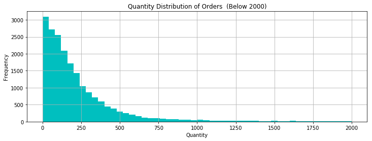

```python
invoice_grouped[invoice_grouped.Quantity < 2000]['Quantity'].hist(bins = 50, figsize = (12, 4), color = 'c')
plt.title('Quantity Distribution of Orders  (Below 2000)')
plt.ylabel('Frequency')
plt.xlabel('Quantity')
```

订单内的商品数量呈现出很典型的长尾分布，大部分订单的商品数量在250件内，商品数量越多，订单数相对越少。

为了进一步探究订单交易金额与订单内商品件数的关系，我们绘制散点图：

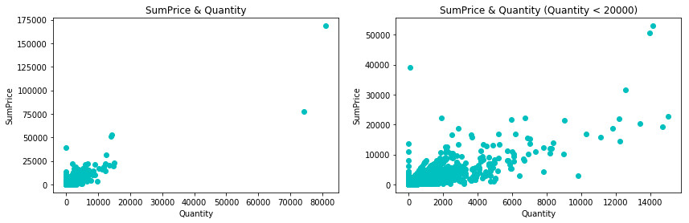

```python
plt.figure(figsize=(14,4))
# plt.subplot用于绘制子图，121表示分成1*2个图片区域，占用第一个。
plt.subplot(121)
plt.scatter(invoice_grouped['Quantity'], invoice_grouped['SumPrice'], color = 'c')
plt.title('SumPrice & Quantity')
plt.ylabel('SumPrice')
plt.xlabel('Quantity')

# 筛去商品件数在20000及以上的订单
plt.subplot(122)
plt.scatter(invoice_grouped[invoice_grouped.Quantity < 20000]['Quantity'], invoice_grouped[invoice_grouped.Quantity < 20000]['SumPrice'], color = 'c')
plt.title('SumPrice & Quantity (Quantity < 20000)')
plt.ylabel('SumPrice')
plt.xlabel('Quantity')
```

总体来说订单交易金额与订单内商品件数是正相关的，订单内的商品数越多，订单金额也相对越高。但在Quantity靠近0的位置也有若干量少高价的订单，后续可以试探究。

### 4.1.2 客户维度

仅对含有CustomerID的客户进行分析：

```python
sales_customer = sales_success[sales_success['CustomerID'] != 0].copy()
```

```python
sales_customer.shape
```

```
(392692, 11)
```

统计各个客户的订单数量、消费金额和商品购买数。先用reset_index重设索引；按客户ID和订单编号分组，对同笔订单的商品数量和销售金额求和；再按客户ID分组：

```python
customer_grouped = sales_customer.groupby(['CustomerID','InvoiceNo'])[['Quantity', 'SumPrice']].sum().reset_index()
```

```python
customer_grouped = customer_grouped.groupby('CustomerID').agg({'InvoiceNo': np.size, 'Quantity': np.sum, 'SumPrice': np.sum})
```

```python
customer_grouped.describe()
```

|  | InvoiceNo | Quantity | SumPrice |
| --- | --- | --- | --- |
| count | 4338.000000 | 4338.000000 | 4338.000000 |
| mean | 4.272015 | 1187.644537 | 2048.688081 |
| std | 7.697998 | 5043.619654 | 8985.230220 |
| min | 1.000000 | 1.000000 | 3.750000 |
| 25% | 1.000000 | 159.000000 | 306.482500 |
| 50% | 2.000000 | 378.000000 | 668.570000 |
| 75% | 5.000000 | 989.750000 | 1660.597500 |
| max | 209.000000 | 196915.000000 | 280206.020000 |

人均购买笔数为4笔，中位数为2笔，25%以上的客户仅下过一次单，并未留存。每位客户平均购买了1187件商品，甚至超过了Q3分位数，最多的客户购买了196915件；客单价为2049英镑，平均值同样超过了Q3分位数，说明客户的购买力存在较大差距，存在小部分的高消费用户拉高了人均数值。

进一步观察客户消费金额的分布：

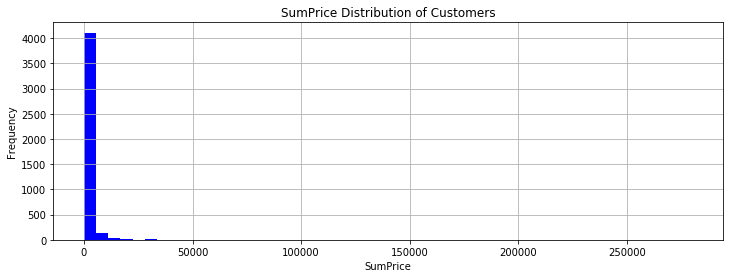

```python
customer_grouped.SumPrice.hist(bins = 50, figsize = (12, 4), color = 'b')
plt.title('SumPrice Distribution of Customers')
plt.ylabel('Frequency')
plt.xlabel('SumPrice')
```

从直方图看，大部分用户的消费能力确实不高，高消费用户在图上几乎看不到。这也确实符合消费行为的行业规律。

截取消费额5000英镑以内的客户：

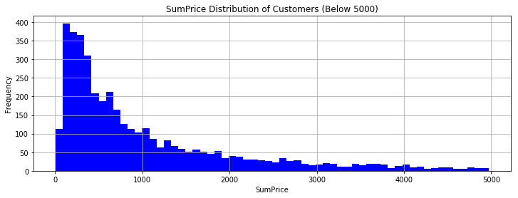

```python
customer_grouped[customer_grouped.SumPrice < 5000].SumPrice.hist(bins = 60, figsize = (12, 4), color = 'b')
plt.title('SumPrice Distribution of Customers (Below 5000)')
plt.ylabel('Frequency')
plt.xlabel('SumPrice')
```

与前面订单金额的多峰分布相比，客户消费金额的分布呈现单峰长尾形态，金额更为集中，峰值在83-333英镑间。

绘制客户消费金额与消费件数的散点图：

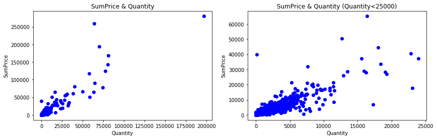

```python
plt.figure(figsize=(14,4))
plt.subplot(121)
plt.scatter(customer_grouped['Quantity'], customer_grouped['SumPrice'], color = 'b')
plt.title('SumPrice & Quantity')
plt.ylabel('SumPrice')
plt.xlabel('Quantity')

plt.subplot(122)
plt.scatter(customer_grouped[customer_grouped.Quantity < 25000]['Quantity'], customer_grouped[customer_grouped.Quantity < 25000]['SumPrice'], color = 'b')
plt.title('SumPrice & Quantity (Quantity<25000)')
plt.ylabel('SumPrice')
plt.xlabel('Quantity')
```

客户群体比较健康，而且规律性比订单更强，同时拥有一定数量消费能力强的用户。总体来说客户的消费金额与购买的商品数量是正相关的，客户购买的东西越多，消费金额相对就越高。

### 4.1.3 商品维度

根据观察，发现相同的商品在不同的订单中单价不同，可知商品的单价会发生波动，以商品10002为例：

```python
sales_success.loc[sales_success['StockCode'] == '10002',:].UnitPrice.value_counts()
```

```
0.85    50
1.66    14
1.63     7
Name: UnitPrice, dtype: int64
```

所以接下来求每件商品的平均价格，思路是平均价格=该商品的总销售额 / 该商品的销售数量。具体来说，先按商品编号进行分组，对数量和总价分别求和，即得到对应商品的总销售金额和总销售量，取商即得到平均价格：

```python
goods_grouped = sales_success.groupby('StockCode')[['Quantity', 'SumPrice']].sum()
```

```python
goods_grouped['AvgPrice'] = goods_grouped['SumPrice'] / goods_grouped['Quantity']
goods_grouped.head()
```

| StockCode | Quantity | SumPrice | AvgPrice |
| --- | --- | --- | --- |
| 10002 | 860 | 759.89 | 0.883593 |
| 10080 | 303 | 119.09 | 0.393036 |
| 10120 | 192 | 40.32 | 0.210000 |
| 10123C | 5 | 3.25 | 0.650000 |
| 10124A | 16 | 6.72 | 0.420000 |

查看所有商品AvgPrice的分布，观察这家店的价格定位：

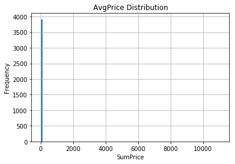

```python
goods_grouped.AvgPrice.hist(bins=100)
plt.title('AvgPrice Distribution')
plt.ylabel('Frequency')
plt.xlabel('SumPrice')
```

发现商品价位基本上全部集中在100英镑内，出现了极少量的天价商品影响观测，将其筛去：

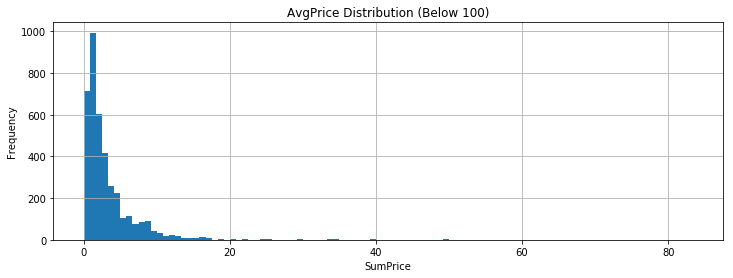

```python
goods_grouped[goods_grouped.AvgPrice < 100].AvgPrice.hist(bins=100,figsize = (12, 4))
plt.title('AvgPrice Distribution (Below 100)')
plt.ylabel('Frequency')
plt.xlabel('SumPrice')
```

峰值是1-2英镑，单价10英镑以上的商品已经很少见，看来该电商的定位主要是价格低的小商品市场。

接下来查看商品单价和商品销量的散点图，可以看出哪种价位的商品更受欢迎：

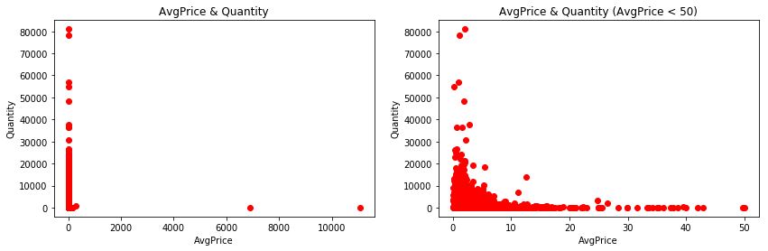

```python
# 商品单价和销售数量的散点图
plt.figure(figsize=(14,4))
plt.subplot(121)
plt.scatter(goods_grouped['AvgPrice'], goods_grouped['Quantity'], color = 'r')
plt.title('AvgPrice & Quantity')
plt.ylabel('Quantity')
plt.xlabel('AvgPrice')

plt.subplot(122)
plt.scatter(goods_grouped[goods_grouped.AvgPrice < 50]['AvgPrice'], goods_grouped[goods_grouped.AvgPrice < 50]['Quantity'], color = 'r')
plt.title('AvgPrice & Quantity (AvgPrice < 50)')
plt.ylabel('Quantity')
plt.xlabel('AvgPrice')
```

从商品的销量上来看，毫无疑问是低于5英镑的低价区商品大获全胜，受到了客户们的喜爱。

那么是否价格低廉的商品也带来了实际上最多的销售额呢？不妨绘制商品单价和商品总销售额的散点图：

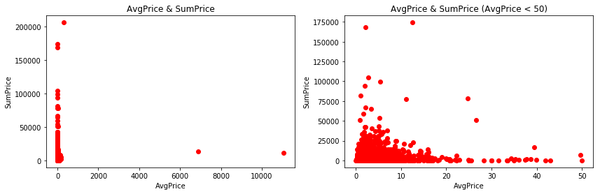

```python
# 商品单价和销售金额的散点图
plt.figure(figsize=(14,4))
plt.subplot(121)
plt.scatter(goods_grouped['AvgPrice'], goods_grouped['SumPrice'], color = 'r')
plt.title('AvgPrice & SumPrice')
plt.ylabel('SumPrice')
plt.xlabel('AvgPrice')

plt.subplot(122)
plt.scatter(goods_grouped[goods_grouped.AvgPrice < 50]['AvgPrice'], goods_grouped[goods_grouped.AvgPrice < 50]['SumPrice'], color = 'r')
plt.title('AvgPrice & SumPrice (AvgPrice < 50)')
plt.ylabel('SumPrice')
plt.xlabel('AvgPrice')
```

低价区的商品笑到了最后，不仅在销售数量上一骑绝尘，也构成了销售额的主要部分；高价的商品虽然单价高昂，但销量很低，并没有带来太多的销售额。据此，建议平台采购部门可以多遴选售价低于10英镑的产品，来进一步扩充低价区的品类。

### 4.1.4 时间维度

按订单号分组，提取出我们需要的信息：

```python
time_grouped = sales_success.groupby('InvoiceNo').agg({'Date': np.min, 'Month': np.min, 'Quantity': np.sum, 'SumPrice': np.sum}).reset_index()
```

这里Date和Month取最小值或最大值都可以，因为都是相同的。

以月份为单位进行折线图绘制，这里对Quantity和SumPrice分组求和，代表每月的销量和销售额，对InvoiceNo计数，代表每月的订单数。此处采用双坐标图，销量和销售额为左轴，参数secondary_y = 'InvoiceNo'表示订单数为右轴：

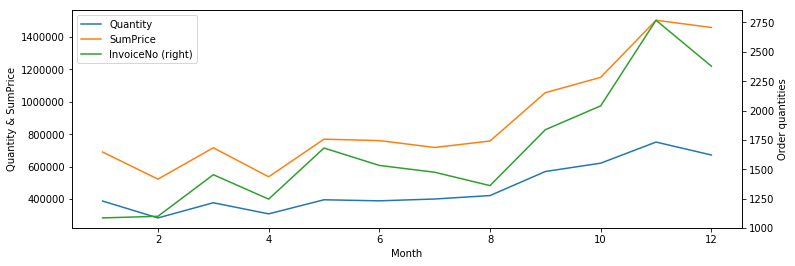

```python
month = time_grouped.groupby('Month').agg({'Quantity': np.sum, 'SumPrice': np.sum, 'InvoiceNo': np.size}).plot(secondary_y = 'InvoiceNo', x_compat=True, figsize = (12, 4))
month.set_ylabel('Quantity & SumPrice')
month.right_ax.set_ylabel('Order quantities')
```

观察到三条折线总体上呈现相近的趋势，除了2011年2月和4月略低外，2010年12月至2011年8月基本维持相近的销售情况；随后在9月-11月连续增长，达到高峰。考虑该电商平台主营礼品，受节日影响可能较大。欧洲重视的万圣节（11月1日）和圣诞节（12月25日）都在年末，与图中的趋势能够相呼应；同时虽然感恩节（11月第4个周四）是美国节日，但“黑五”的营销方式对全球都产生了一定影响。

将日期设为索引，按日绘制折线图：

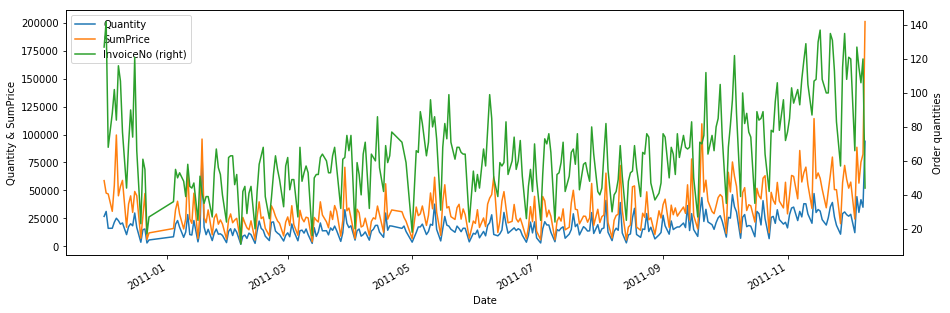

```python
time_grouped = time_grouped.set_index('Date')
day = time_grouped.groupby('Date').agg({'Quantity': np.sum, 'SumPrice': np.sum, 'InvoiceNo': np.size}).plot(secondary_y = 'InvoiceNo', figsize = (15, 5))
day.set_ylabel('Quantity & SumPrice')
day.right_ax.set_ylabel('Order quantities')
```

可见销量Quantity和销售额SumPrice的趋势是极趋同的，这也和前一节中分析出该电商以低价商品为主相吻合，商品单价低且价位集中，则销售额主要随销量变化而涨跌。

注意到在最后一天（即2011年12月9日），销量、销售额显著激增，我们放大看看：

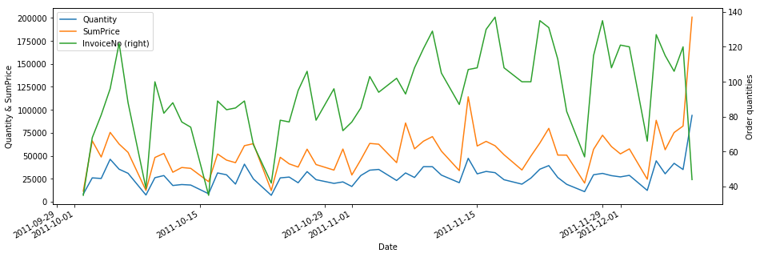

```python
day_part = time_grouped['2011-10-01':'2011-12-09'].groupby('Date').agg({'Quantity': np.sum, 'SumPrice': np.sum, 'InvoiceNo': np.size}).plot(
    secondary_y = 'InvoiceNo', figsize = (15, 5))
day_part.set_ylabel('Quantity & SumPrice')
day_part.right_ax.set_ylabel('Order quantities')
```

2011年12月的前8天基本延续了11月下旬的销售趋势，但在12月9日订单量大幅下降时，却创造了样本区间内销量和销售额的历史新高。说明存在某笔或某几笔购买量极大的订单，从而使得销售额大幅上升。

将当日的销售详单拉取出来：

```python
sales_success[sales_success.Date == '2011-12-09'].sort_values(by = 'SumPrice', ascending = False).head()
```

|  | InvoiceNo | StockCode | Description | Quantity | InvoiceTime | UnitPrice | CustomerID | Country | Date | Month | SumPrice |
| --- | --- | --- | --- | --- | --- | --- | --- | --- | --- | --- | --- |
| 535160 | 581483 | 23843 | PAPER CRAFT , LITTLE BIRDIE | 80995 | 2011-12-09 09:15:00 | 2.08 | 16446 | United Kingdom | 2011-12-09 | 12 | 168469.60 |
| 536279 | 581498 | DOT | DOTCOM POSTAGE | 1 | 2011-12-09 10:26:00 | 1714.17 | 0 | United Kingdom | 2011-12-09 | 12 | 1714.17 |
| 535647 | 581492 | DOT | DOTCOM POSTAGE | 1 | 2011-12-09 10:03:00 | 933.17 | 0 | United Kingdom | 2011-12-09 | 12 | 933.17 |
| 535164 | 581485 | 20749 | ASSORTED COLOUR MINI CASES | 84 | 2011-12-09 09:38:00 | 6.35 | 17389 | United Kingdom | 2011-12-09 | 12 | 533.40 |
| 536434 | 581566 | 23404 | HOME SWEET HOME BLACKBOARD | 144 | 2011-12-09 11:50:00 | 3.26 | 18102 | United Kingdom | 2011-12-09 | 12 | 469.44 |

### 4.1.5 区位维度

首先提取出一张客户ID及其国家的关系表:

```python
sales_country = sales_success[['CustomerID', 'Country']].drop_duplicates()
```

按客户分组，计算消费总额：

```python
country_grouped = sales_customer.groupby('CustomerID')[['SumPrice']].sum()
```

将上述两张表合并：

```python
country_grouped = country_grouped.merge(sales_country, on=['CustomerID'])
```

按国家再次分组，计算出各国客户的消费总额和客户总数：

```python
country_grouped = country_grouped.groupby('Country').agg({'SumPrice': np.sum, 'CustomerID': np.size})
```

新增AvgAmount字段，用于存放该国家客户的人均消费金额：

```python
country_grouped['AvgAmount'] = country_grouped['SumPrice'] / country_grouped['CustomerID']
```

对消费总额降序排列：

```python
country_grouped.sort_values(by = 'SumPrice',ascending = False).head(20)
```

| Country | SumPrice | CustomerID | AvgAmount |
| --- | --- | --- | --- |
| United Kingdom | 7285024.644 | 3920 | 1858.424654 |
| Netherlands | 285446.340 | 9 | 31716.260000 |
| EIRE | 265262.460 | 3 | 88420.820000 |
| Germany | 228678.400 | 94 | 2432.748936 |
| France | 208934.310 | 87 | 2401.543793 |
| Australia | 139843.950 | 9 | 15538.216667 |
| Spain | 66470.260 | 30 | 2215.675333 |
| Switzerland | 57222.850 | 21 | 2724.897619 |
| Belgium | 47971.210 | 25 | 1918.848400 |
| Sweden | 38367.830 | 8 | 4795.978750 |
| Japan | 37416.370 | 8 | 4677.046250 |
| Norway | 36165.440 | 10 | 3616.544000 |
| Portugal | 33375.840 | 19 | 1756.623158 |
| Finland | 22546.080 | 12 | 1878.840000 |
| Singapore | 21279.290 | 1 | 21279.290000 |
| Channel Islands | 20440.540 | 9 | 2271.171111 |
| Denmark | 19774.400 | 9 | 2197.155556 |
| Italy | 17483.240 | 14 | 1248.802857 |
| Austria | 16775.840 | 11 | 1525.076364 |
| Cyprus | 16518.540 | 8 | 2064.817500 |

可知绝大部分客户仍来自英国本土，主要境外收入来源也多为英国周边国家，基本上符合以英国为圆心向外辐射的情况。这种现象可能和运输成本及语言等有关，也可能是影响力随距离而衰减，可以尝试增加境外的宣传投放，提高知名度；同时建议网站做好多国语言的适配，也可以在网站上对于境外物流费用计算及手续办理等事项给出更易懂的说明。

## 4.2 客户消费行为分析

### 4.2.1 客户的生命周期

该数据集的统计对象为2010年12月1日至2011年12月9日的全部订单，我们这节研究的客户是指所有成功的普通订单中有CustomerID的客户，不包含未记录CustomerID的客户，下同。

其实样本中的客户有许多未进行完整的生命周期 ，我们并不知道在统计时段前他们是否购买过，也不知道在统计时段后他们中的哪些会继续购买。所以这里计算的生命周期是有局限性的，真实的客户平均生命周期必然会更长。

首先筛选出CustomerID不为空的客户（NaN之前被我们填充为0）：

```python
sales_customer = sales_success[sales_success['CustomerID'] != 0].copy()
```

查看用户的初次与末次（最近）消费时间：

```python
# 客户的初次消费时间
mindate = sales_customer.groupby('CustomerID')[['Date']].min()
# 客户的末次消费时间
maxdate = sales_customer.groupby('CustomerID')[['Date']].max()
```

查看用户的初次/末次消费集中在哪些日期：

```python
mindate.Date.value_counts().head(10)
```

```
2010-12-01    95
2010-12-02    93
2010-12-08    83
2010-12-06    70
2010-12-05    69
2010-12-09    67
2010-12-16    58
2010-12-07    50
2010-12-03    46
2010-12-15    42
Name: Date, dtype: int64
```

```python
maxdate.Date.value_counts().head(10)
```

```
2011-12-08    103
2011-12-06     94
2011-12-05     94
2011-12-07     90
2011-12-01     79
2011-11-29     77
2011-11-22     74
2011-12-02     72
2011-11-30     71
2011-11-17     64
Name: Date, dtype: int64
```

发现初次消费的高频日期为统计时段的初期，末次消费的高频日期为统计时段的末期。说明有大量用户的生命周期被低估，实际上还要向前向后延伸。

末次消费日期减去初次消费日期得到统计时段内的生命周期，展示前5行：

```python
(maxdate - mindate).head()
```

| CustomerID | Date |
| --- | --- |
| 12346 | 0 days |
| 12347 | 365 days |
| 12348 | 283 days |
| 12349 | 0 days |
| 12350 | 0 days |

0 days表示该客户只在某一天内消费过，未能留存。

再看一下客户生命周期的总体情况:

```python
life_time = maxdate - mindate
life_time.describe()
```

|  | Date |
| --- | --- |
| count | 4338 |
| mean | 130 days 18:31:02.240663 |
| std | 132 days 05:03:08.004046 |
| min | 0 days 00:00:00 |
| 25% | 0 days 00:00:00 |
| 50% | 93 days 00:00:00 |
| 75% | 252 days 00:00:00 |
| max | 373 days 00:00:00 |

共有4338个有CustomerID的客户，其平均生命周期为130天，中位数则是93天，说明有部分生命周期很长的忠实客户拉高了均值；而最小值和Q1分位数都为0天，说明存在25%以上的客户仅消费了一次，生命周期的分布呈两极分化的状态。

接下来，绘制柱形图观察客户生命周期的实际分布。

这里的时间差是timedelta类型，无法绘制柱形图，将其先转化为数值：

```python
life_time['life_time'] = life_time['Date'].dt.days
```

绘制20个分组的柱形图：

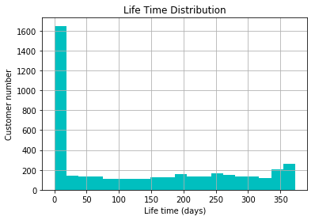

```python
life_time['life_time'].hist(bins = 20, color = 'c')
plt.title('Life Time Distribution')
plt.ylabel('Customer number')
plt.xlabel('Life time (days)')
```

许多客户仅消费过一次，没有留存下来，需要更加重视客户初次购买的体验感，可以考虑通过网站内服务评价、客服电询等方式获知新客对于购买流程中不满意之处，针对性地加以改进；同时应该对新客采取吸引其二次购买的手段，如发放有时限的优惠券等。有趣的是在350天左右出现一个次高峰，不妨将生命周期为0天的客户排除掉再看看分布：

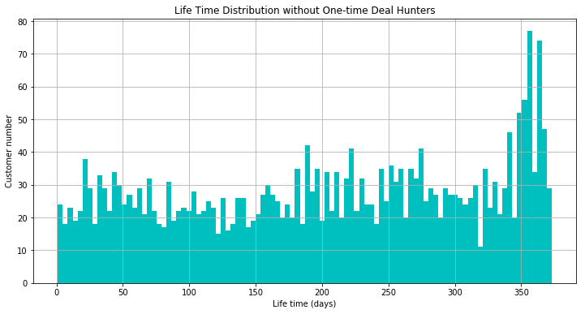

```python
# 将分组增多至100，并拉宽图表的尺寸
life_time[life_time['life_time'] > 0].life_time.hist(bins = 100, figsize = (12, 6), color = 'c')
plt.title('Life Time Distribution without One-time Deal Hunters')
plt.ylabel('Customer number')
plt.xlabel('Life time (days)')
```

这个数据漂亮得有些惊人。生命周期在0-75天的客户数略高于75-170天，可以考虑加强前70天内对客户的引导。约1/4的客户集中在170天-330天，属于较高质量客户的生命周期；而在330天以后，则是数量可观的死忠客户，拥有极高的用户粘性。考虑到这些客户中有许多未进行完整的生命周期 ，实际的客户平均生命周期会更长。

```python
# 消费两次及以上的用户平均生命周期
life_time[life_time['life_time'] > 0].life_time.mean()
```

```
203.32867383512544
```

### 4.2.2 客户的留存情况

客户的生命周期实际上是首次和末次消费的时间差，故无法对客户各月的消费情况获得直观的感受。因此接下来我们对客户的留存情况展开探究。这里需要说明的是，同样由于样本统计区间的缘故，我们无法判断2010年12月1日至2011年12月9日内的首次消费是否是该客户的历史首次消费。

先将用户首次消费日期合并进sales_customer中，suffixes参数是对重名的字段自定义后缀：

```python
customer_retention = sales_customer.merge(mindate, on = 'CustomerID', how = 'inner', suffixes = ('', 'Min'))
```

新增字段DateDiff，用于存放本次消费日期与首次消费日期的时间差，并转为数值：

```python
customer_retention['DateDiff'] = (customer_retention.Date - customer_retention.DateMin).dt.days
```

```python
date_bins = [0, 3, 7, 30, 60, 90, 180]
customer_retention['DateDiffBin'] = pd.cut(customer_retention.DateDiff, bins = date_bins)
customer_retention['DateDiffBin'].value_counts()
```

```
(90, 180]    74528
(30, 60]     28252
(60, 90]     25876
(7, 30]      17148
(3, 7]        3559
(0, 3]        1311
Name: DateDiffBin, dtype: int64
```

DateDiffBin代表客户该笔订单的消费时间距其首次消费属于哪个时间段。因为计算的是留存，如果客户仅消费了一次（当日多次消费也视作一次），我们认为该客户是流失了的，这里DateDiff=0，并不会被划分入(0, 3]天的开闭区间内。

接下来用pivot_table作数据透视表，这里index相当于数据透视表的行，columns相当于列，values表示聚合对象，aggfunc表示聚合方法。对SumPrice求和，获得的结果是客户首次消费后，在后续各时间段内的消费总金额：

```python
retention_pivot = customer_retention.pivot_table(index = ['CustomerID'], columns = ['DateDiffBin'], values = ['SumPrice'], aggfunc= np.sum)
```

```python
retention_pivot.head(10)
```

| DateDiffBin CustomerID | SumPrice (0, 3] | SumPrice (3, 7] | SumPrice (7, 30] | SumPrice (30, 60] | SumPrice (60, 90] | SumPrice (90, 180] |
| --- | --- | --- | --- | --- | --- | --- |
| 12347 | NaN | NaN | NaN | 475.39 | NaN | 636.25 |
| 12348 | NaN | NaN | NaN | 227.44 | NaN | 367.00 |
| 12352 | NaN | NaN | 1104.98 | 160.33 | NaN | NaN |
| 12356 | NaN | NaN | NaN | NaN | 481.46 | NaN |
| 12358 | NaN | NaN | NaN | NaN | NaN | 683.20 |
| 12359 | NaN | NaN | 1838.91 | NaN | NaN | 1109.32 |
| 12360 | NaN | NaN | NaN | NaN | 534.70 | 1043.78 |
| 12362 | NaN | NaN | NaN | NaN | 495.24 | 773.01 |
| 12363 | NaN | NaN | NaN | NaN | NaN | 252.90 |
| 12364 | NaN | NaN | NaN | 79.80 | 299.06 | 310.32 |

NaN表示该客户在该区间内未进行过消费，聚合值全为NaN的客户会被过滤，即透视表中全为消费2次及以上的留存客户。

将数据转换成是否，1代表在该时间段内有后续消费，0代表没有：

```python
retention_pivot_trans = retention_pivot.fillna(0).applymap(lambda x: 1 if x>0 else 0)
```

```python
retention_pivot_trans.head(10)
```

| DateDiffBin CustomerID | SumPrice (0, 3] | SumPrice (3, 7] | SumPrice (7, 30] | SumPrice (30, 60] | SumPrice (60, 90] | SumPrice (90, 180] |
| --- | --- | --- | --- | --- | --- | --- |
| 12347 | 0 | 0 | 0 | 1 | 0 | 1 |
| 12348 | 0 | 0 | 0 | 1 | 0 | 1 |
| 12352 | 0 | 0 | 1 | 1 | 0 | 0 |
| 12356 | 0 | 0 | 0 | 0 | 1 | 0 |
| 12358 | 0 | 0 | 0 | 0 | 0 | 1 |
| 12359 | 0 | 0 | 1 | 0 | 0 | 1 |
| 12360 | 0 | 0 | 0 | 0 | 1 | 1 |
| 12362 | 0 | 0 | 0 | 0 | 1 | 1 |
| 12363 | 0 | 0 | 0 | 0 | 0 | 1 |
| 12364 | 0 | 0 | 0 | 1 | 1 | 1 |

统计留存客户首次消费后各时间段内的购买率，这里对各列中的1求和，再除以计数值：

```python
(retention_pivot_trans.sum()/ retention_pivot_trans.count())
```

```
          DateDiffBin
SumPrice  (0, 3]         0.032075
          (3, 7]         0.066179
          (7, 30]        0.270808
          (30, 60]       0.405197
          (60, 90]       0.373934
          (90, 180]      0.678035
dtype: float64
```

```
为了方便直观感受，绘制为柱形图：
```

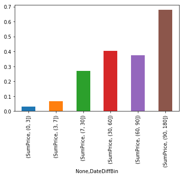

```python
(retention_pivot_trans.sum()/ retention_pivot_trans.count()).plot(kind='bar')
```

### 4.2.3 客户的购买周期

接下来计算客户的购买周期，思路是对其相邻两次消费日期相减，这里我们通过之前得到的DateDiff来运算。

对customer_retention去除客户编号和消费日期都相同的重复数据（即相同订单的不同商品），参数keep='first'表示保留重复值中的第一条；由于要考虑到相邻的问题，再对日期进行升序排序：

```python
sales_cycle = customer_retention.drop_duplicates(subset=['CustomerID', 'Date'],keep='first')
sales_cycle.sort_values(by = 'Date',ascending = True)
```

|  | InvoiceNo | StockCode | Description | Quantity | InvoiceTime | UnitPrice | CustomerID | Country | Date | Month | SumPrice | DateMin | DateDiff | DateDiffBin |
| --- | --- | --- | --- | --- | --- | --- | --- | --- | --- | --- | --- | --- | --- | --- |
| 0 | 536365 | 85123A | WHITE HANGING HEART T-LIGHT HOLDER | 6 | 2010-12-01 08:26:00 | 2.55 | 17850 | United Kingdom | 2010-12-01 | 12 | 15.30 | 2010-12-01 | 0 | NaN |
| 32284 | 536588 | 22960 | JAM MAKING SET WITH JARS | 6 | 2010-12-01 16:49:00 | 4.25 | 17069 | United Kingdom | 2010-12-01 | 12 | 25.50 | 2010-12-01 | 0 | NaN |
| 32262 | 536587 | 37448 | CERAMIC CAKE DESIGN SPOTTED MUG | 12 | 2010-12-01 16:33:00 | 1.49 | 14142 | United Kingdom | 2010-12-01 | 12 | 17.88 | 2010-12-01 | 0 | NaN |
| 6814 | 536405 | 20914 | SET/5 RED RETROSPOT LID GLASS BOWLS | 128 | 2010-12-01 11:32:00 | 2.55 | 14045 | United Kingdom | 2010-12-01 | 12 | 326.40 | 2010-12-01 | 0 | NaN |
| 6820 | 536408 | 22537 | MAGIC DRAWING SLATE DINOSAUR | 24 | 2010-12-01 11:41:00 | 0.42 | 14307 | United Kingdom | 2010-12-01 | 12 | 10.08 | 2010-12-01 | 0 | NaN |
| 7000 | 536409 | 90199C | 5 STRAND GLASS NECKLACE CRYSTAL | 3 | 2010-12-01 11:45:00 | 6.35 | 17908 | United Kingdom | 2010-12-01 | 12 | 19.05 | 2010-12-01 | 0 | NaN |
| 7054 | 536412 | 20728 | LUNCH BAG CARS BLUE | 3 | 2010-12-01 11:49:00 | 1.65 | 17920 | United Kingdom | 2010-12-01 | 12 | 4.95 | 2010-12-01 | 0 | NaN |
| 32098 | 536586 | 22846 | BREAD BIN DINER STYLE RED | 8 | 2010-12-01 16:25:00 | 14.95 | 18229 | United Kingdom | 2010-12-01 | 12 | 119.60 | 2010-12-01 | 0 | NaN |
| 32069 | 536585 | 37449 | CERAMIC CAKE STAND + HANGING CAKES | 2 | 2010-12-01 16:24:00 | 9.95 | 17460 | United Kingdom | 2010-12-01 | 12 | 19.90 | 2010-12-01 | 0 | NaN |
| 31972 | 536582 | 21668 | RED STRIPE CERAMIC DRAWER KNOB | 12 | 2010-12-01 16:21:00 | 1.25 | 12947 | United Kingdom | 2010-12-01 | 12 | 15.00 | 2010-12-01 | 0 | NaN |
| 7719 | 536415 | 22952 | 60 CAKE CASES VINTAGE CHRISTMAS | 10 | 2010-12-01 11:57:00 | 0.55 | 12838 | United Kingdom | 2010-12-01 | 12 | 5.50 | 2010-12-01 | 0 | NaN |
| 7839 | 536416 | 21494 | ROTATING LEAVES T-LIGHT HOLDER | 12 | 2010-12-01 11:58:00 | 1.25 | 13255 | United Kingdom | 2010-12-01 | 12 | 15.00 | 2010-12-01 | 0 | NaN |
| 7852 | 536420 | 21889 | WOODEN BOX OF DOMINOES | 12 | 2010-12-01 12:03:00 | 1.25 | 16583 | United Kingdom | 2010-12-01 | 12 | 15.00 | 2010-12-01 | 0 | NaN |
| 7866 | 536423 | 22619 | SET OF 6 SOLDIER SKITTLES | 4 | 2010-12-01 12:08:00 | 3.75 | 18085 | United Kingdom | 2010-12-01 | 12 | 15.00 | 2010-12-01 | 0 | NaN |
| 7895 | 536425 | 22837 | HOT WATER BOTTLE BABUSHKA | 8 | 2010-12-01 12:08:00 | 4.65 | 13758 | United Kingdom | 2010-12-01 | 12 | 37.20 | 2010-12-01 | 0 | NaN |
| 31720 | 536578 | 22837 | HOT WATER BOTTLE BABUSHKA | 12 | 2010-12-01 16:15:00 | 4.65 | 17690 | United Kingdom | 2010-12-01 | 12 | 55.80 | 2010-12-01 | 0 | NaN |
| 8012 | 536437 | 21154 | RED RETROSPOT OVEN GLOVE | 200 | 2010-12-01 12:12:00 | 1.06 | 13694 | United Kingdom | 2010-12-01 | 12 | 212.00 | 2010-12-01 | 0 | NaN |
| 31523 | 536575 | 21864 | UNION JACK FLAG PASSPORT COVER | 72 | 2010-12-01 16:01:00 | 1.69 | 13777 | United Kingdom | 2010-12-01 | 12 | 121.68 | 2010-12-01 | 0 | NaN |
| 6730 | 536404 | 22297 | HEART IVORY TRELLIS SMALL | 24 | 2010-12-01 11:29:00 | 1.25 | 16218 | United Kingdom | 2010-12-01 | 12 | 30.00 | 2010-12-01 | 0 | NaN |
| 6728 | 536403 | 22867 | HAND WARMER BIRD DESIGN | 96 | 2010-12-01 11:27:00 | 1.85 | 12791 | Netherlands | 2010-12-01 | 12 | 177.60 | 2010-12-01 | 0 | NaN |
| 32427 | 536590 | 22969 | HOMEMADE JAM SCENTED CANDLES | 12 | 2010-12-01 16:52:00 | 1.45 | 13065 | United Kingdom | 2010-12-01 | 12 | 17.40 | 2010-12-01 | 0 | NaN |
| 32441 | 536591 | 21427 | SKULLS STORAGE BOX SMALL | 1 | 2010-12-01 16:57:00 | 2.10 | 14606 | United Kingdom | 2010-12-01 | 12 | 2.10 | 2010-12-01 | 0 | NaN |
| 3681 | 536385 | 22783 | SET 3 WICKER OVAL BASKETS W LIDS | 1 | 2010-12-01 09:56:00 | 19.95 | 17420 | United Kingdom | 2010-12-01 | 12 | 19.95 | 2010-12-01 | 0 | NaN |
| 3711 | 536386 | 84880 | WHITE WIRE EGG HOLDER | 36 | 2010-12-01 09:57:00 | 4.95 | 16029 | United Kingdom | 2010-12-01 | 12 | 178.20 | 2010-12-01 | 0 | NaN |
| 3952 | 536388 | 21754 | HOME BUILDING BLOCK WORD | 3 | 2010-12-01 09:59:00 | 5.95 | 16250 | United Kingdom | 2010-12-01 | 12 | 17.85 | 2010-12-01 | 0 | NaN |
| 3976 | 536389 | 22941 | CHRISTMAS LIGHTS 10 REINDEER | 6 | 2010-12-01 10:03:00 | 8.50 | 12431 | Australia | 2010-12-01 | 12 | 51.00 | 2010-12-01 | 0 | NaN |
| 4210 | 536390 | 22941 | CHRISTMAS LIGHTS 10 REINDEER | 2 | 2010-12-01 10:19:00 | 8.50 | 17511 | United Kingdom | 2010-12-01 | 12 | 17.00 | 2010-12-01 | 0 | NaN |
| 5173 | 536392 | 22150 | 3 STRIPEY MICE FELTCRAFT | 6 | 2010-12-01 10:29:00 | 1.95 | 13705 | United Kingdom | 2010-12-01 | 12 | 11.70 | 2010-12-01 | 0 | NaN |
| 5201 | 536393 | 22180 | RETROSPOT LAMP | 8 | 2010-12-01 10:37:00 | 9.95 | 13747 | United Kingdom | 2010-12-01 | 12 | 79.60 | 2010-12-01 | 0 | NaN |
| 5202 | 536394 | 21506 | FANCY FONT BIRTHDAY CARD, | 24 | 2010-12-01 10:39:00 | 0.42 | 13408 | United Kingdom | 2010-12-01 | 12 | 10.08 | 2010-12-01 | 0 | NaN |
| ... | ... | ... | ... | ... | ... | ... | ... | ... | ... | ... | ... | ... | ... | ... |
| 15551 | 581476 | 23198 | PANTRY MAGNETIC SHOPPING LIST | 48 | 2011-12-09 08:48:00 | 1.25 | 12433 | Norway | 2011-12-09 | 12 | 60.00 | 2010-12-01 | 373 | NaN |
| 95306 | 581566 | 23404 | HOME SWEET HOME BLACKBOARD | 144 | 2011-12-09 11:50:00 | 3.26 | 18102 | United Kingdom | 2011-12-09 | 12 | 469.44 | 2010-12-07 | 367 | NaN |
| 151515 | 581572 | 23328 | SET 6 SCHOOL MILK BOTTLES IN CRATE | 48 | 2011-12-09 12:08:00 | 3.39 | 16705 | United Kingdom | 2011-12-09 | 12 | 162.72 | 2010-12-16 | 358 | NaN |
| 150423 | 581486 | 22910 | PAPER CHAIN KIT VINTAGE CHRISTMAS | 12 | 2011-12-09 09:38:00 | 2.95 | 17001 | United Kingdom | 2011-12-09 | 12 | 35.40 | 2010-12-16 | 358 | NaN |
| 147654 | 581477 | 48111 | DOORMAT 3 SMILEY CATS | 10 | 2011-12-09 08:59:00 | 7.08 | 13426 | United Kingdom | 2011-12-09 | 12 | 70.80 | 2010-12-15 | 359 | NaN |
| 165893 | 581493 | 79190B | RETRO PLASTIC POLKA TRAY | 15 | 2011-12-09 10:10:00 | 0.42 | 12423 | Belgium | 2011-12-09 | 12 | 6.30 | 2010-12-21 | 353 | NaN |
| 311098 | 581585 | 22481 | BLACK TEA TOWEL CLASSIC DESIGN | 12 | 2011-12-09 12:31:00 | 0.39 | 15804 | United Kingdom | 2011-12-09 | 12 | 4.68 | 2011-05-25 | 198 | NaN |
| 146425 | 581489 | 22061 | LARGE CAKE STAND HANGING STRAWBERY | 48 | 2011-12-09 09:46:00 | 2.95 | 16954 | United Kingdom | 2011-12-09 | 12 | 141.60 | 2010-12-15 | 359 | NaN |
| 384384 | 581501 | 22319 | HAIRCLIPS FORTIES FABRIC ASSORTED | 180 | 2011-12-09 10:46:00 | 0.19 | 12985 | United Kingdom | 2011-12-09 | 12 | 34.20 | 2011-11-11 | 28 | (7, 30] |
| 76396 | 581488 | 23118 | PARISIENNE JEWELLERY DRAWER | 16 | 2011-12-09 09:45:00 | 6.65 | 17428 | United Kingdom | 2011-12-09 | 12 | 106.40 | 2010-12-06 | 368 | NaN |
| 351348 | 581574 | 22326 | ROUND SNACK BOXES SET OF4 WOODLAND | 6 | 2011-12-09 12:09:00 | 2.95 | 12526 | Germany | 2011-12-09 | 12 | 17.70 | 2011-09-06 | 94 | (90, 180] |
| 35657 | 581487 | 21137 | BLACK RECORD COVER FRAME | 120 | 2011-12-09 09:44:00 | 3.39 | 15694 | United Kingdom | 2011-12-09 | 12 | 406.80 | 2010-12-02 | 372 | NaN |
| 321448 | 581481 | 21115 | ROSE CARAVAN DOORSTOP | 8 | 2011-12-09 09:07:00 | 1.95 | 17490 | United Kingdom | 2011-12-09 | 12 | 15.60 | 2011-06-16 | 176 | (90, 180] |
| 208026 | 581502 | 22087 | PAPER BUNTING WHITE LACE | 6 | 2011-12-09 10:51:00 | 2.95 | 15910 | United Kingdom | 2011-12-09 | 12 | 17.70 | 2011-01-27 | 316 | NaN |
| 283743 | 581538 | 23193 | BUFFALO BILL TREASURE BOOK BOX | 6 | 2011-12-09 11:34:00 | 2.25 | 14446 | United Kingdom | 2011-12-09 | 12 | 13.50 | 2011-04-07 | 246 | NaN |
| 31716 | 581583 | 20725 | LUNCH BAG RED RETROSPOT | 40 | 2011-12-09 12:23:00 | 1.45 | 13777 | United Kingdom | 2011-12-09 | 12 | 58.00 | 2010-12-01 | 373 | NaN |
| 101654 | 581496 | 22664 | TOY TIDY DOLLY GIRL DESIGN | 20 | 2011-12-09 10:20:00 | 0.79 | 16558 | United Kingdom | 2011-12-09 | 12 | 15.80 | 2010-12-08 | 366 | NaN |
| 14315 | 581580 | 23334 | IVORY WICKER HEART SMALL | 4 | 2011-12-09 12:20:00 | 0.63 | 12748 | United Kingdom | 2011-12-09 | 12 | 2.52 | 2010-12-01 | 373 | NaN |
| 275119 | 581480 | 23463 | VINTAGE ZINC WATERING CAN | 2 | 2011-12-09 09:07:00 | 9.95 | 14441 | United Kingdom | 2011-12-09 | 12 | 19.90 | 2011-03-29 | 255 | NaN |
| 361857 | 581500 | 82486 | 3 DRAWER ANTIQUE WHITE WOOD CABINET | 4 | 2011-12-09 10:45:00 | 8.95 | 15344 | United Kingdom | 2011-12-09 | 12 | 35.80 | 2011-09-26 | 74 | (60, 90] |
| 342348 | 581494 | 23084 | RABBIT NIGHT LIGHT | 24 | 2011-12-09 10:13:00 | 1.79 | 12518 | Germany | 2011-12-09 | 12 | 42.96 | 2011-08-21 | 110 | (90, 180] |
| 104204 | 581495 | 23535 | WALL ART BICYCLE SAFETY | 12 | 2011-12-09 10:20:00 | 5.95 | 14051 | United Kingdom | 2011-12-09 | 12 | 71.40 | 2010-12-08 | 366 | NaN |
| 14901 | 581570 | 22141 | CHRISTMAS CRAFT TREE TOP ANGEL | 6 | 2011-12-09 11:59:00 | 2.10 | 12662 | Germany | 2011-12-09 | 12 | 12.60 | 2010-12-01 | 373 | NaN |
| 307133 | 581483 | 23843 | PAPER CRAFT , LITTLE BIRDIE | 80995 | 2011-12-09 09:15:00 | 2.08 | 16446 | United Kingdom | 2011-12-09 | 12 | 168469.60 | 2011-05-18 | 205 | NaN |
| 341701 | 581587 | 22631 | CIRCUS PARADE LUNCH BOX | 12 | 2011-12-09 12:50:00 | 1.95 | 12680 | France | 2011-12-09 | 12 | 23.40 | 2011-08-18 | 113 | (90, 180] |
| 265252 | 581567 | 21417 | COCKLE SHELL DISH | 84 | 2011-12-09 11:56:00 | 0.79 | 16626 | United Kingdom | 2011-12-09 | 12 | 66.36 | 2011-03-18 | 266 | NaN |
| 105570 | 581586 | 22061 | LARGE CAKE STAND HANGING STRAWBERY | 8 | 2011-12-09 12:49:00 | 2.95 | 13113 | United Kingdom | 2011-12-09 | 12 | 23.60 | 2010-12-08 | 366 | NaN |
| 263687 | 581516 | 21109 | LARGE CAKE TOWEL CHOCOLATE SPOTS | 12 | 2011-12-09 11:26:00 | 1.95 | 14422 | United Kingdom | 2011-12-09 | 12 | 23.40 | 2011-03-17 | 267 | NaN |
| 60536 | 581475 | 22596 | CHRISTMAS STAR WISH LIST CHALKBOARD | 36 | 2011-12-09 08:39:00 | 0.39 | 13069 | United Kingdom | 2011-12-09 | 12 | 14.04 | 2010-12-05 | 369 | NaN |
| 392654 | 581578 | POST | POSTAGE | 3 | 2011-12-09 12:16:00 | 18.00 | 12713 | Germany | 2011-12-09 | 12 | 54.00 | 2011-12-09 | 0 | NaN |

16763 rows × 14 columns

定义函数diff，用于计算相邻两次消费的时间差：

```python
def diff(group):
    d = group.DateDiff - group.DateDiff.shift()
    return d
```

shift()是往上偏移一个位置，shift(-1)是往下偏移一个位置，求客户本次消费与上次消费的时间间隔，用当前值减去shift()即可。若为NaN，则仅消费过一次。

先按客户编码分组，在应用diff函数：

```python
last_diff = sales_cycle.groupby('CustomerID').apply(diff)
```

```python
last_diff.head(10)
```

```
CustomerID
12346       193894     NaN
12347       93546      NaN
            93577     50.0
            93606     71.0
            93630     63.0
            93648     54.0
            93670     90.0
            93717     37.0
12348       156820     NaN
            156837    40.0
Name: DateDiff, dtype: float64
```

第一列为客户编码，第二列是索引值，第三列表示本次消费同上次消费的时间差。

画出按订单统计的购买周期柱状图，查看其分布：

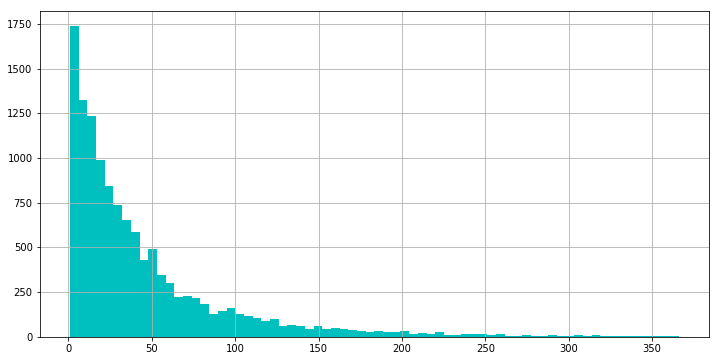

```python
last_diff.hist(bins = 70, figsize = (12, 6), color = 'c')
```

典型的长尾分布，大部分购买行为的消费间隔比较短。但这是所有订单的购买周期分布，并不是对客户个体为统计单位的购买周期分布。故对客户编号进行分组：

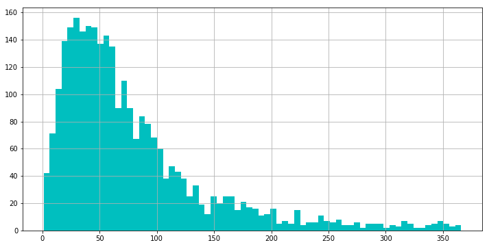

```python
last_diff_customer = last_diff.groupby('CustomerID').mean()
last_diff_customer.hist(bins = 70, figsize = (12, 6), color = 'c')
```

一个右偏分布，峰值在15-70天，说明大部分留存客户的购买周期集中于此。建议可以每隔30天左右对客户进行些优惠活动的信息推送，比较符合大部分老客户的购买周期。

# 5. 小结

1.订单维度：

有效订单共19960笔，笔单价为533.17英镑，连带率约为279件。订单以批发性质为主，订单间差异较大，存在部分购买力极强的客户。总体来说订单交易金额与订单内商品件数正相关。

2.客户维度：

客单价为2049英镑，客户的购买力存在较大差距，拥有一定数量消费能力强的客户。客户群体比较健康，其消费金额与购买商品数量正相关，而且规律性比订单更强。

3.商品维度：

商品的单价会发生波动，集中于1-2英镑，定位主要是低价的小商品市场。低于5英镑的商品最受客户喜爱，同时也构成了销售额的主要部分。高价的商品虽然单价不菲，但销量很低，并没有带来太多的销售额。建议平台采购部门可以多遴选售价低于10英镑的产品，来进一步扩充低价区的品类。

4.时间维度：

订单数、销量、销售额总体上呈现相近的趋势， 在2011年9月-11月连续增长，达到高峰。考虑到主营商品为礼品，猜测受节日影响可能较大，如万圣节（11月1日）和圣诞节（12月25日），也可能受到“黑五”（11月第4个周四）影响。商品单价低且价位集中，销售额主要随销量变化而涨跌。

5.区位维度：

绝大部分客户来自英国本土，主要境外收入也多来自周边国家，基本上符合以英国为圆心向外辐射的情况。可能和运输成本及语言等有关，也可能是影响力随距离而衰减。可以考虑增加境外的宣传投放，提高知名度；同时建议网站做好多国语言的适配。

7.留存情况：

8.购买周期：

大部分留存客户的购买周期集中在15-70天，建议可以每隔30天左右对客户进行些优惠活动的信息推送。#

# 二 运用RFM模型分析客户价值

识别客户价值应用最广泛的模型就是通过三个指标（最近消费间隔(Recency),消费频率(Frequency)和消费金额(Monetary)）进行客户细分，识别出高价值用户，简称RFM模型

### 1 数据处理

首先筛选出CustomerID不为空的客户

```python
sales_customer = sales_success[sales_success['CustomerID'] != 0].copy()
sales_customer.head()
```

|  | InvoiceNo | StockCode | Description | Quantity | InvoiceTime | UnitPrice | CustomerID | Country | Date | Month | SumPrice |
| --- | --- | --- | --- | --- | --- | --- | --- | --- | --- | --- | --- |
| 0 | 536365 | 85123A | WHITE HANGING HEART T-LIGHT HOLDER | 6 | 2010-12-01 08:26:00 | 2.55 | 17850 | United Kingdom | 2010-12-01 | 12 | 15.30 |
| 1 | 536365 | 71053 | WHITE METAL LANTERN | 6 | 2010-12-01 08:26:00 | 3.39 | 17850 | United Kingdom | 2010-12-01 | 12 | 20.34 |
| 2 | 536365 | 84406B | CREAM CUPID HEARTS COAT HANGER | 8 | 2010-12-01 08:26:00 | 2.75 | 17850 | United Kingdom | 2010-12-01 | 12 | 22.00 |
| 3 | 536365 | 84029G | KNITTED UNION FLAG HOT WATER BOTTLE | 6 | 2010-12-01 08:26:00 | 3.39 | 17850 | United Kingdom | 2010-12-01 | 12 | 20.34 |
| 4 | 536365 | 84029E | RED WOOLLY HOTTIE WHITE HEART. | 6 | 2010-12-01 08:26:00 | 3.39 | 17850 | United Kingdom | 2010-12-01 | 12 | 20.34 |

新建一张表储存所需要的特征

```python
customer_data = pd.DataFrame({'CustomerID':sales_customer['CustomerID'].drop_duplicates()})
```

```python
customer_data.head(10)
```

|  | CustomerID |
| --- | --- |
| 0 | 17850 |
| 9 | 13047 |
| 26 | 12583 |
| 46 | 13748 |
| 65 | 15100 |
| 82 | 15291 |
| 86 | 14688 |
| 105 | 17809 |
| 106 | 15311 |
| 142 | 16098 |

查看用户末次消费时间

```python
maxdate = sales_customer.groupby('CustomerID')['Date'].max()
maxdate.head()
```

```
CustomerID
12346   2011-01-18
12347   2011-12-07
12348   2011-09-25
12349   2011-11-21
12350   2011-02-02
Name: Date, dtype: datetime64[ns]
```

因为该数据集为英国在线零售商在2010年12月1日至2011年12月9日，我们去用户末次消费时间与2011年12月9日的差值作为最近消费间隔

```python
mdate = pd.to_datetime('2011-12-9')
R_data = (mdate-maxdate).dt.days
```

```python
customer_data = customer_data.merge(pd.DataFrame(R_data).reset_index().rename(columns={'Date':'R'}),on='CustomerID',how='inner')
```

取累积购买次数作为消费频率

```python
F_data = sales_customer[['CustomerID','InvoiceNo']].drop_duplicates().groupby('CustomerID')['InvoiceNo'].count()
```

```python
customer_data = customer_data.merge(pd.DataFrame(F_data).reset_index().rename(columns={'InvoiceNo':'F'}),on='CustomerID',how='inner')
```

取总销售金额作为销售金额

```python
M_data = sales_customer.groupby('CustomerID')['SumPrice'].sum()
```

```python
customer_data = customer_data.merge(pd.DataFrame(M_data).reset_index().rename(columns={'SumPrice':'M'}),on='CustomerID',how='inner')
```

```python
customer_data.describe()
```

|  | CustomerID | R | F | M |
| --- | --- | --- | --- | --- |
| count | 4338.000000 | 4338.000000 | 4338.000000 | 4338.000000 |
| mean | 15300.408022 | 92.059474 | 4.272015 | 2048.688081 |
| std | 1721.808492 | 100.012264 | 7.697998 | 8985.230220 |
| min | 12346.000000 | 0.000000 | 1.000000 | 3.750000 |
| 25% | 13813.250000 | 17.000000 | 1.000000 | 306.482500 |
| 50% | 15299.500000 | 50.000000 | 2.000000 | 668.570000 |
| 75% | 16778.750000 | 141.750000 | 5.000000 | 1660.597500 |
| max | 18287.000000 | 373.000000 | 209.000000 | 280206.020000 |

### 2 归一化处理

```python
from sklearn.preprocessing import StandardScaler
from sklearn import metrics
import warnings
warnings.filterwarnings('ignore')
```

```python
sd = StandardScaler()
data = sd.fit_transform(customer_data.ix[:,['R','F','M']])
```

```python
data = pd.DataFrame(data,columns=['ZR','ZF','ZM'])
```

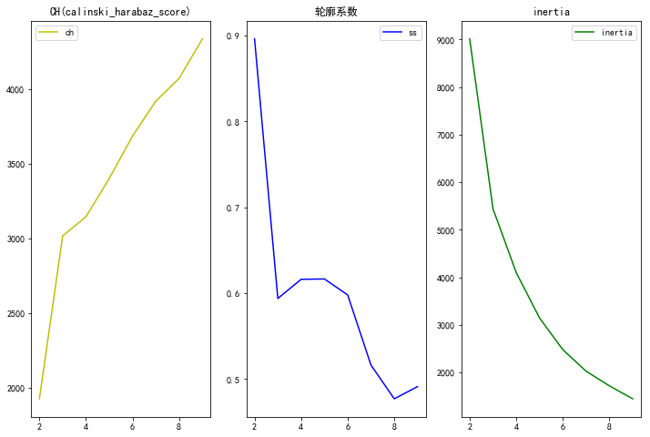

```python
from sklearn.cluster import KMeans
k = np.arange(2,10)

ch_score = []
ss_score = []
inertia = []
for i in k:
    model = KMeans(n_clusters = i, max_iter = 300, n_init = 10, init = 'k-means++', random_state = 0)
    pred = model.fit_predict(data)
    ch = metrics.calinski_harabaz_score(data,pred)
    ss = metrics.silhouette_score(data,pred)
    ch_score.append(ch)
    ss_score.append(ss)
    inertia.append(model.inertia_)

# 做图对比
fig = plt.figure(figsize=(12,8))
ax1 = fig.add_subplot(131)
plt.plot(list(range(2,10)),ch_score,label='ch',c='y')
plt.title('CH(calinski_harabaz_score)')
plt.legend()

ax2 = fig.add_subplot(132)
plt.plot(list(range(2,10)),ss_score,label='ss',c='b')
plt.title('轮廓系数')
plt.legend()

ax3 = fig.add_subplot(133)
plt.plot(list(range(2,10)),inertia,label='inertia',c='g')
plt.title('inertia')
plt.legend()
plt.rcParams['font.sans-serif'] = ['SimHei']
plt.rcParams['font.serif'] = ['SimHei']  # 设置正常显示中文
plt.show()
```

```python
model = KMeans(n_clusters = 3, max_iter = 500, n_init = 10, init = 'k-means++', random_state = 0)
model.fit_predict(data)
```

```
array([0, 1, 1, ..., 1, 1, 1])
```

```python
# 聚类标签
labels = pd.Series(model.labels_)
# 聚类中心
centers = pd.DataFrame(model.cluster_centers_)
```

```python
result1=pd.concat([centers,labels.value_counts().sort_index(ascending=True)],axis=1)
result1.columns = list(customer_data.columns[1:])+['counts']
result1
```

|  | R | F | M | counts |
| --- | --- | --- | --- | --- |
| 0 | 1.540617 | -0.349559 | -0.157917 | 1087 |
| 1 | -0.512290 | 0.052723 | -0.021952 | 3225 |
| 2 | -0.865973 | 8.074597 | 9.324975 | 26 |

```python
result = pd.concat([customer_data,labels],axis=1)
result.columns = list(customer_data.columns)+['label']
result.head()
```

|  | CustomerID | R | F | M | label |
| --- | --- | --- | --- | --- | --- |
| 0 | 17850 | 372 | 34 | 5391.21 | 0 |
| 1 | 13047 | 31 | 10 | 3237.54 | 1 |
| 2 | 12583 | 2 | 15 | 7281.38 | 1 |
| 3 | 13748 | 95 | 5 | 948.25 | 1 |
| 4 | 15100 | 333 | 3 | 876.00 | 0 |

```python
pd.options.display.max_columns = None  # 设定展示所有的列
print(result.groupby(['label']).agg('mean').ix[:,1:]) # 分组计算各指标的均值
```

```
                R          F             M
label
0      246.122355   1.581417    629.931399
1       40.830078   4.677829   1851.471452
2        5.461538  66.423077  85826.078077
```

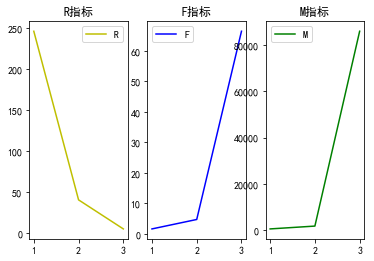

```python
s = result.groupby(['label']).agg('mean').ix[:,1:]
fig = plt.figure()
ax1= fig.add_subplot(131)
ax1.plot(list(range(1,4)),s.R,c='y',label='R')
plt.title('R指标')
plt.legend()
ax2= fig.add_subplot(132)
ax2.plot(list(range(1,4)),s.F,c='b',label='F')
plt.title('F指标')
plt.legend()
ax3= fig.add_subplot(133)
ax3.plot(list(range(1,4)),s.M,c='g',label='M')
plt.title('M指标')
plt.legend()
plt.show()
```

- 第一类：R最高，F和M最低，说明距离上次消费时间很久了，且近一年消费频率和消费金额接近于0，属于已流失和已沉默用户，建议通过短信或email等方式召回或唤醒
- 第二类：R、F和M均比较低，活跃度一般，消费能力一般，属于仍在活跃但忠诚度不高的客户，建议对其进行一些品牌上的宣传，同时通过活动刺激他们多活跃多消费，提高忠诚度
- 第三类：R低，F和M高，说明最近刚消费，且销售频率和消费金额高的用户，属于高价值用户，需要重点照顾。